# Report of Experimental Research Designs

Salvatore Mancino B34000061

30/03/2022

# The dataset

The data set that I chose for my project contains 6 variables measured on 300 statistical units. In particular, the statistical units are male and females living in one of three states of the United States of America: Wisconsin, Iowa and Connecticut. 100 people were randomly selected from each state. For each person a measure of tolerance towards black people was measured through a Likert Scale questionnaire before and after watching one between two movies (everything took place in a single day). In both cases, the total minimum tolerance score that one could obtain was 0 (completely racist) while the total maximum was 100 (completely tolerant). So, my analysis will be focused on understanding racism phenomenon in these 3 states and seeing if any observed difference due to various factors is statistically significant.

The 6 variables are:

- id: unique identifier for each person;
- gender: gender of people;
- state: state in which people live;
- movie: which movie subjects have seen;
- premovie: tolerance measure before watching the movie;
- postmovie: tolerance measure after watching the movie;

First of all, I change the type of some of the variables:

```r
racism$id <- as.factor(racism$id)
racism$gender <- as.factor(racism$gender)
racism$state <- as.factor(racism$state)
racism$movie <- as.factor(racism$movie)
racism$premovie <- as.numeric(racism$premovie)
racism$postmovie <- as.numeric(racism$postmovie)
```

Let’s explore the data set by providing a summary of the variables:

```r
print(dfSummary(racism,
                varnumbers =  FALSE,
                valid.col = FALSE,
                graph.magnif = 0.75),
      method = 'render')
```

Data Frame Summary

racism

**Dimensions**: 300 x 6  
**Duplicates**: 0

| **Variable** | **Stats / Values** | **Freqs (% of Valid)** | **Graph** | **Missing** |
| --- | --- | --- | --- | --- |
| id [factor] | 1. 1 2. 2 3. 3 4. 4 5. 5 6. 6 7. 7 8. 8 9. 9 10. 10 [ 290 others ] | 1 ( 0.3% ) 1 ( 0.3% ) 1 ( 0.3% ) 1 ( 0.3% ) 1 ( 0.3% ) 1 ( 0.3% ) 1 ( 0.3% ) 1 ( 0.3% ) 1 ( 0.3% ) 1 ( 0.3% ) 290 ( 96.7% ) |  | 0 (0.0%) |
| gender [factor] | 1. Female 2. Male | 150 ( 50.0% ) 150 ( 50.0% ) |  | 0 (0.0%) |
| state [factor] | 1. Connecticut 2. Iowa 3. Wisconsin | 100 ( 33.3% ) 100 ( 33.3% ) 100 ( 33.3% ) |  | 0 (0.0%) |
| movie [factor] | 1. 12 Years a Slave 2. To Kill A Mocking | 150 ( 50.0% ) 150 ( 50.0% ) |  | 0 (0.0%) |
| premovie [numeric] | Mean (sd) : 28.5 (8.3) min ≤ med ≤ max: 0 ≤ 28 ≤ 55 IQR (CV) : 10 (0.3) | 43 distinct values |  | 0 (0.0%) |
| postmovie [numeric] | Mean (sd) : 37.5 (18.2) min ≤ med ≤ max: 0 ≤ 37 ≤ 91 IQR (CV) : 24.2 (0.5) | 76 distinct values |  | 0 (0.0%) |

Generated by summarytools 1.0.0 ([R](https://www.r-project.org/) version 4.1.1)  
2022-03-28

# Pre-movie tolerance vs post-movie tolerance (paired t-test)

First of all, I want to check if watching the movies (without any distinction between the two movies) has had an effect in increasing people’s tolerance towards black people, so I have to proceed with a paired t-test.

Let’s check the assumptions to see if I can proceed with the parametric approach:

1. Observations must be dependent over time (True);
2. Observations must be collected randomly; (True)
3. Paired differences are normally distributed. (To be checked)

The first two assumptions are met because people were randomly selected from each state and for each person a measure of tolerance was computed before and after watching a movie, through the same questionnaire.

In order to check whether the normality assumption is met, let’s compute the paired differences and let’s look at the QQ-plot:

```r
# I compute the paired differences...
racism <- racism %>%
  mutate(paired_differences = postmovie - premovie)
head(racism)
```

```
## # A tibble: 6 x 7
##   id    gender state     movie             premovie postmovie paired_differences
##   <fct> <fct>  <fct>     <fct>                <dbl>     <dbl>              <dbl>
## 1 1     Male   Wisconsin To Kill A Mocking       24        39                 15
## 2 2     Female Wisconsin To Kill A Mocking       22        35                 13
## 3 3     Female Wisconsin To Kill A Mocking       20        39                 19
## 4 4     Female Wisconsin To Kill A Mocking        0        20                 20
## 5 5     Male   Wisconsin To Kill A Mocking       21        27                  6
## 6 6     Female Wisconsin To Kill A Mocking       30        47                 17
```

```r
detach(racism)
attach(racism)
```

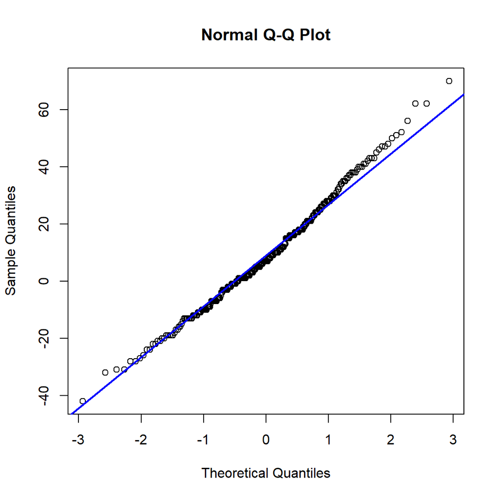

```r
# ...QQ-plot
qqnorm(paired_differences)
qqline(paired_differences,
       lwd = 2,
       col = "blue")
```

It looks like the normality assumption is met, but to be sure let’s also test the assumption through the shapiro.wilk test:

```r
shapiro.test(paired_differences)
```

```
##
##  Shapiro-Wilk normality test
##
## data:  paired_differences
## W = 0.99152, p-value = 0.08269
```

The p-value is > 0.05, so the the null hypothesis is accepted and I can state that the paired differences of the tolerance measure pre and post movies follow a normal distribution.

All the assumptions are met, so I can proceed with the parametric t-test, whose hypothesis are:

H0: mean(postmovie) - mean(premovie) = 0 H1: mean(postmovie) - mean(premovie) > 0

Graphically:

```r
long_racism <- racism %>%
  dplyr::select(id, gender, movie, premovie, postmovie)
long_racism <- long_racism %>%
  gather(key = "time", value = "tolerance", premovie, postmovie) %>%
  convert_as_factor(id, time)
long_racism$time <- factor(long_racism$time, levels = c("premovie", "postmovie"))
```

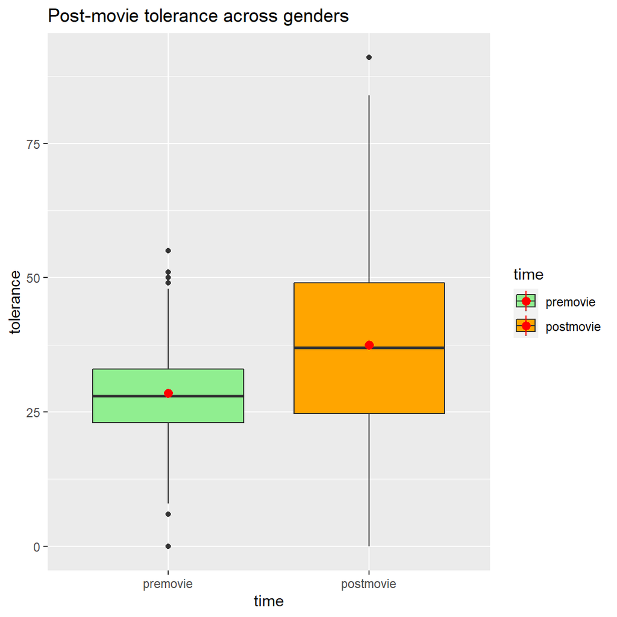

```r
ggplot(long_racism, aes(x=time, y=tolerance, fill=time)) +
  geom_boxplot() +
  stat_summary(fun.y="mean", color = "red") +
  scale_fill_manual(values = c("lightgreen", "orange")) +
  ggtitle("Post-movie tolerance across genders")
```

There seem to be a difference between the means, but we have to check if it is statistically significant.

```r
t.test(postmovie, premovie, paired = TRUE, alternative = "greater")
```

```
##
##  Paired t-test
##
## data:  postmovie and premovie
## t = 8.1217, df = 299, p-value = 6.092e-15
## alternative hypothesis: true difference in means is greater than 0
## 95 percent confidence interval:
##  7.097228      Inf
## sample estimates:
## mean of the differences
##                8.906667
```

Since p-value is essentially 0, I reject the null hypothesis and I can state that the average tolerance towards black people after watching the movies is statistically significantly greater than the average tolerance towards black people before watching the movies, so watching the movies has actually had a real effect in increasing tolerance towards black people.

I also provide an alternative procedure, e.i., I compute the test statistic step by step.

I have already computed the paired differences. Now I compute the observed test statistic *mean difference*:

```r
d_hat <- racism %>%
  specify(response = paired_differences) %>%
  calculate(stat = "mean")
d_hat
```

```
## Response: paired_differences (numeric)
## # A tibble: 1 x 1
##    stat
##   <dbl>
## 1  8.91
```

```r
SE = sd(paired_differences)/sqrt(length(paired_differences)) # standard error
```

```r
# Observed standardized test statistic
t = d_hat/SE
t = as.numeric(t)
t
```

```
## [1] 8.121686
```

```r
pvalue = pt(t, df = as.numeric(length(paired_differences)) - 1, lower.tail = FALSE)
pvalue
```

```
## [1] 6.09163e-15
```

As I expected I get the exact same results as before and of course the interpretation is the same.